# Capture Recapture Algorithm

Diptanshu Singh

December 1, 2018

## Capture Recapture

Mark and recapture is a method commonly used in ecology to estimate an animal population’s size. A portion of the population is captured, marked, and released. Later, another portion is captured and the number of marked individuals within the sample is counted. Since the number of marked individuals within the second sample should be proportional to the number of marked individuals in the whole population, an estimate of the total population size can be obtained by dividing the number of marked individuals by the proportion of marked individuals in the second sample. In order to approximate it better, this process is performed again and again. The method is most useful when it is not practical to count all the individuals in the population.

First defining helper functions:

```r
rhat <- function (sims, ...)
  rstan::monitor(sims, print = FALSE, ...)[, "Rhat"]
neff_ratio <- function (sims, ...)
  rstan::monitor(sims, print = FALSE, ...)[, "n_eff"]

# format expected by `bayesplot`: iterations, chains, params
# Create for storing the markov chains.
# ns - number of posterior draws
# nchains - number of independent chains
# nparams - number of parameters

mcmc_array <- function (ns, nchains, params) {
  nparams <- length(params)
  array(dim = c(ns, nchains, nparams),
        dimnames = list(iterations = NULL,
                        chains = paste0("chain", 1:nchains),
                        parameters = params))
}
```

Defining gibbs sampler for posterior density

```r
log_posterior <- function (N, alpha, captured, r) {
  lgamma(N + 1) - lgamma(N - r + 1) +
    sum(captured * log(alpha) + (N - captured) * log(1 - alpha))
}

sample_chain <- function (ns, captured, r, N0, alpha0) {
  k <- length(captured)
  N <- integer(ns)
  alpha <- matrix(nrow = ns, ncol = k)
  lp <- numeric(ns)
  N[1] <- N0; alpha[1,] <- alpha0
  lp[1] <- log_posterior(N[1], alpha[1], captured, r)
  for (is in 2:ns) {
    N[is] <- r + rnbinom(1, r + 1, 1 - prod(1 - alpha[is - 1,]))
    alpha[is,] <- rbeta(k, captured + 1, N[is] - captured + 1)
    lp[is] <- log_posterior(N[is], alpha[is,], captured, r)
  }
  list(N = N, alpha = alpha, lp = lp)
}
```

We are performing capture and mark again and again, and noting down the number of newly marked animals. So here, captured[2] = 22 and marked_new[2] = 8 mean that in the 2nd round, 22 were captured, out of 8 were not marked. 14 were already marked, so 8 new ones were marked.

Demo Example:

captured <- c(30, 22, 29, 26, 31, 32, 35) marked_new <- c(30, 8, 17, 7, 9, 8, 5)

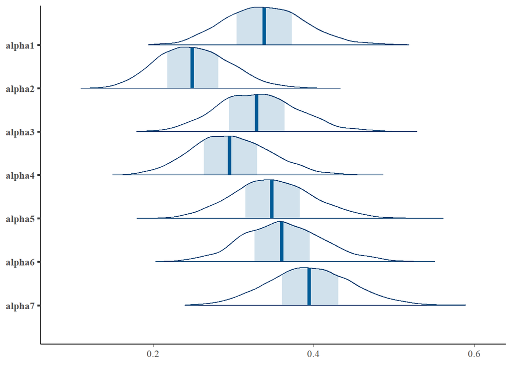

```r
captured <- c(30, 22, 29, 26, 31, 32, 35)
marked_new <- c(30, 8, 17, 7, 9, 8, 5)
r <- sum(marked_new)

ns <- 1000; nchains <- 4
params <- c("N", paste0("alpha", seq_along(captured)), "lp")
sims <- mcmc_array(ns, nchains, params)
N0 <- r; # Starting estimate at the total marked animals
alpha0 <- captured / N0
for (ic in 1:nchains) {
  ch <- sample_chain(ns, captured, r, N0, alpha0)
  sims[, ic, ] <- cbind(ch$N, ch$alpha, ch$lp)
  sims[, ic, 1] <- ch$N
  sims[, ic, 1 + seq_along(captured)] <- ch$alpha
  sims[, ic, 2 + length(captured)] <- ch$lp
}

color_scheme_set("mix-blue-red")
mcmc_areas(sims, pars = paste0("alpha", seq_along(captured)))
```

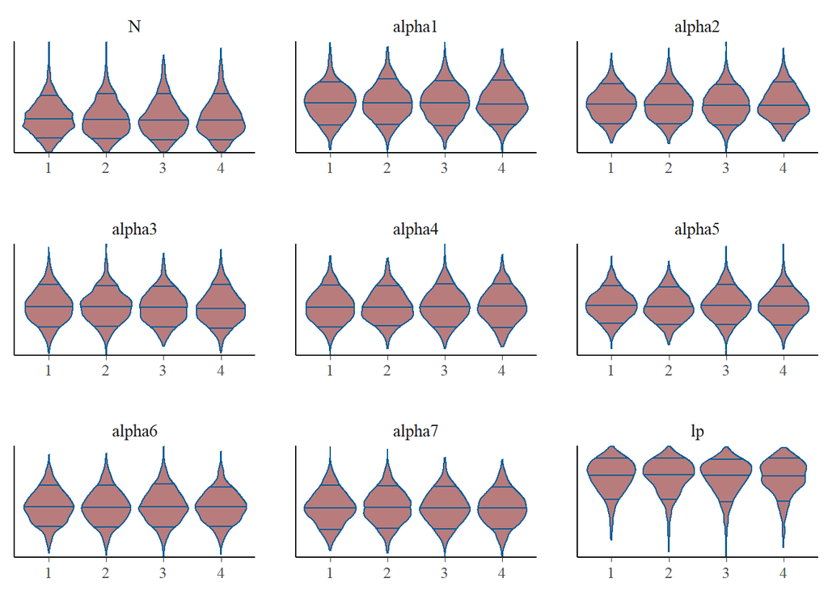

```r
mcmc_violin(sims)
```

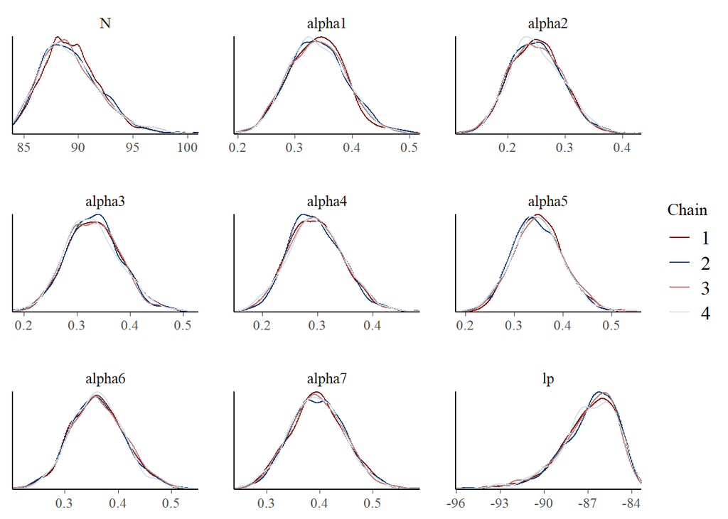

```r
mcmc_dens_overlay(sims)
```

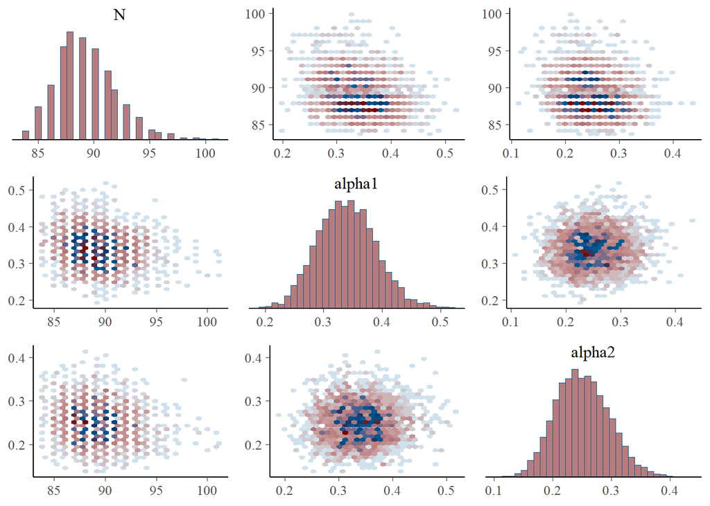

```r
mcmc_pairs(sims, pars = c("N", "alpha1", "alpha2"),
           diag_fun = "hist", off_diag_fun = "hex")
```

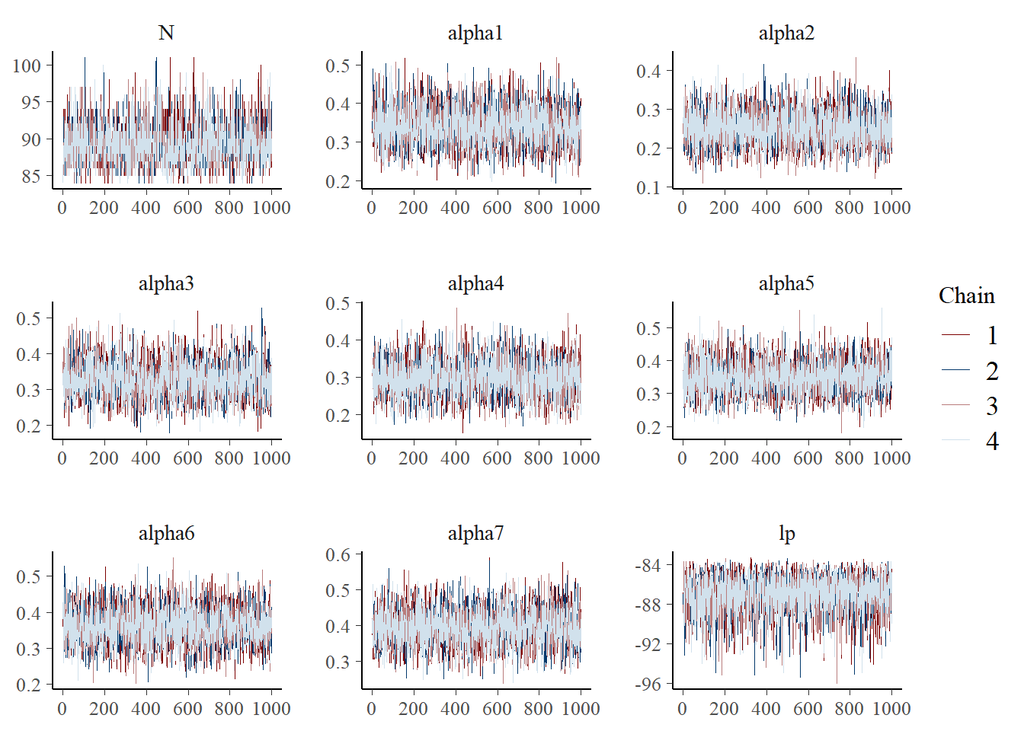

```r
mcmc_trace(sims)
```

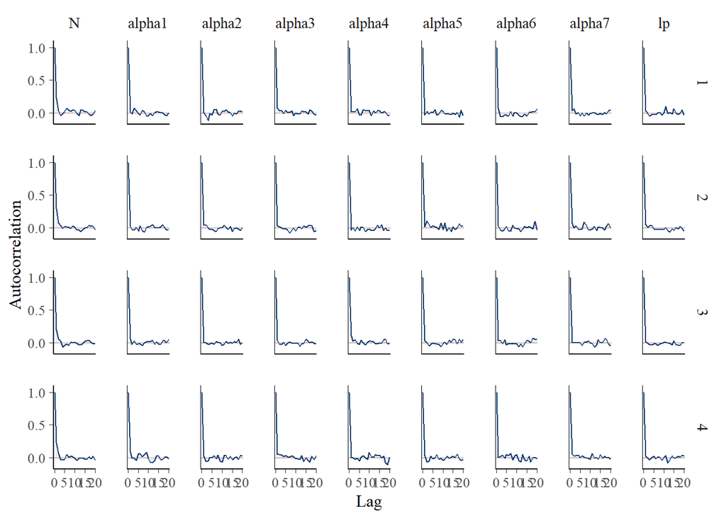

```r
mcmc_acf(sims)
```

We will now use the MAP estimate to find the population:

```r
# [ extra: MAP estimates ]
N <- N0;
alpha <- alpha0;
tol <- 1e-6
k <- length(captured)
g <- numeric(k + 1);
H <- matrix(0, nrow = k + 1, ncol = k + 1)
l <- log_posterior(N, alpha, captured, r)
repeat {
  #The functions digamma and trigamma return the first and second derivatives of the logarithm of the gamma function.
  g[1] <- digamma(N + 1) - digamma(N - r + 1) + sum(log(1 - alpha))
  g[-1] <- captured / alpha - (N - captured) / (1 - alpha)
  H[1, 1] <- trigamma(N + 1) - trigamma(N - r + 1)
  H[1, -1] <- H[-1, 1] <- -1 / (1 - alpha)
  diag(H[-1, -1]) <- -captured / alpha ^ 2 - (N - captured) / (1 - alpha) ^ 2
  C <- chol(-H)
  delta <- backsolve(C, backsolve(C, g, transpose = TRUE))
  N <- N + delta[1]; alpha <- alpha + delta[-1]
  l.new <- log_posterior(N, alpha, captured, r)
  if (abs((l.new - l) / l) < tol) break
  l <- l.new
}

N
```

```
## [1] 88.8491
```

The total population is estimated to be 89